# StatsProject1

Haizhu Hong

7/29/2020

Detailed Analysis

6.Potential transformation 7.Try price vs. carat+cut, carat+color, carat+clarity and relate results to Part III C 8.Compare R squared, adjusted R squared, SSresiduals, calculate PRESS, AIC or BIC with the full model 9.BoxCox plots and levene test to drop extreme values 10.Relate to part III Log transformation

```r
data<-read.csv(file='clean_diamond_data.csv')
attach(data)
# Treat clarity color and cut as categorical factors
clarity <- factor(clarity)
color <- factor(color)
cut <- factor(cut)
# Define calpress function to return PRESS stats
calpress <- function(linear.model) {
  pr <- residuals(linear.model)/(1 - lm.influence(linear.model)$hat)
  press <- sum(pr^2)
  return(press)
}
# Define calsst function to return sst stats
calsst <- function(linear.model){
  sst <- sum(anova(linear.model)$'Sum Sq')
  return(sst)
}
```

Try fit full model without transformation

```r
fullreg <- lm(price~carat+clarity+color+cut)
summary(fullreg)
```

```
##
## Call:
## lm(formula = price ~ carat + clarity + color + cut)
##
## Residuals:
##     Min      1Q  Median      3Q     Max
##  -95976   -4234    1186    4379 1932205
##
## Coefficients:
##               Estimate Std. Error t value Pr(>|t|)
## (Intercept)    9961.34     538.52  18.497  < 2e-16 ***
## carat         24512.88      45.76 535.640  < 2e-16 ***
## clarityIF    -18567.14     496.50 -37.396  < 2e-16 ***
## claritySI1   -23210.90     479.61 -48.395  < 2e-16 ***
## claritySI2   -23752.02     483.99 -49.076  < 2e-16 ***
## clarityVS1   -21794.88     480.01 -45.405  < 2e-16 ***
## clarityVS2   -22571.31     480.41 -46.984  < 2e-16 ***
## clarityVVS1  -20138.46     482.18 -41.766  < 2e-16 ***
## clarityVVS2  -20688.67     481.81 -42.939  < 2e-16 ***
## colorE         -240.19     112.43  -2.136   0.0326 *
## colorF         -846.05     111.88  -7.562 3.97e-14 ***
## colorG        -2117.49     113.88 -18.594  < 2e-16 ***
## colorH        -3109.97     120.80 -25.745  < 2e-16 ***
## colorI        -3328.87     122.70 -27.131  < 2e-16 ***
## colorJ        -5311.58     142.94 -37.159  < 2e-16 ***
## cutGood       -1866.38     283.59  -6.581 4.68e-11 ***
## cutIdeal       1634.42     258.44   6.324 2.55e-10 ***
## cutVery Good  -1333.65     261.94  -5.091 3.56e-07 ***
## ---
## Signif. codes:  0 '***' 0.001 '**' 0.01 '*' 0.05 '.' 0.1 ' ' 1
##
## Residual standard error: 14790 on 210620 degrees of freedom
## Multiple R-squared:  0.5829, Adjusted R-squared:  0.5829
## F-statistic: 1.732e+04 on 17 and 210620 DF,  p-value: < 2.2e-16
```

```r
anova(fullreg)
```

```
## Analysis of Variance Table
##
## Response: price
##               Df     Sum Sq    Mean Sq   F value    Pr(>F)
## carat          1 6.2388e+13 6.2388e+13 285262.35 < 2.2e-16 ***
## clarity        7 1.0463e+12 1.4948e+11    683.47 < 2.2e-16 ***
## color          6 4.9624e+11 8.2707e+10    378.17 < 2.2e-16 ***
## cut            3 4.4944e+11 1.4981e+11    685.00 < 2.2e-16 ***
## Residuals 210620 4.6063e+13 2.1870e+08
## ---
## Signif. codes:  0 '***' 0.001 '**' 0.01 '*' 0.05 '.' 0.1 ' ' 1
```

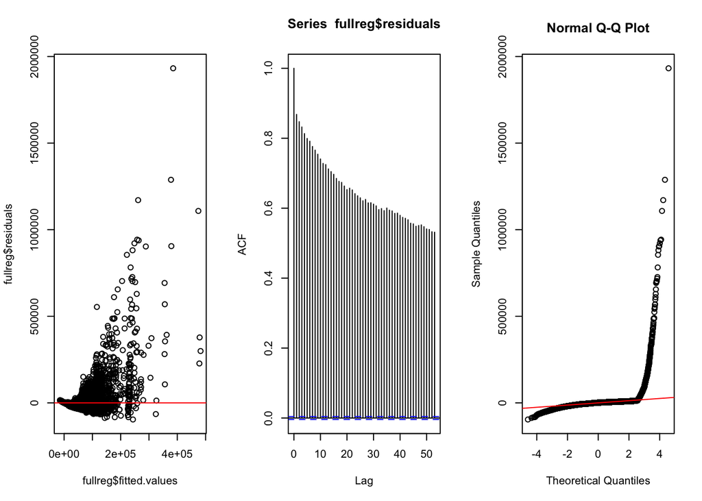

```r
par(mfrow=c(1,3))
plot(fullreg$fitted.values,fullreg$residuals)
abline(h=0,col="red")
acf(fullreg$residuals)
qqnorm(fullreg$residuals)
qqline(fullreg$residuals,col="red")
```

Try regress price against carat and clarity

```r
clarityreg <- lm(price~carat+clarity)
summary(clarityreg)
```

```
##
## Call:
## lm(formula = price ~ carat + clarity)
##
## Residuals:
##     Min      1Q  Median      3Q     Max
##  -93462   -4315    1523    4477 1936595
##
## Coefficients:
##              Estimate Std. Error t value Pr(>|t|)
## (Intercept)  11383.20     477.39   23.84   <2e-16 ***
## carat        24048.03      45.59  527.50   <2e-16 ***
## clarityIF   -20578.70     498.65  -41.27   <2e-16 ***
## claritySI1  -25542.17     480.54  -53.15   <2e-16 ***
## claritySI2  -26418.81     484.41  -54.54   <2e-16 ***
## clarityVS1  -24116.22     481.16  -50.12   <2e-16 ***
## clarityVS2  -24907.25     481.33  -51.75   <2e-16 ***
## clarityVVS1 -22463.79     483.33  -46.48   <2e-16 ***
## clarityVVS2 -23099.73     482.95  -47.83   <2e-16 ***
## ---
## Signif. codes:  0 '***' 0.001 '**' 0.01 '*' 0.05 '.' 0.1 ' ' 1
##
## Residual standard error: 14940 on 210629 degrees of freedom
## Multiple R-squared:  0.5744, Adjusted R-squared:  0.5743
## F-statistic: 3.553e+04 on 8 and 210629 DF,  p-value: < 2.2e-16
```

```r
anova(clarityreg)
```

```
## Analysis of Variance Table
##
## Response: price
##               Df     Sum Sq    Mean Sq   F value    Pr(>F)
## carat          1 6.2388e+13 6.2388e+13 279535.69 < 2.2e-16 ***
## clarity        7 1.0463e+12 1.4948e+11    669.75 < 2.2e-16 ***
## Residuals 210629 4.7009e+13 2.2318e+08
## ---
## Signif. codes:  0 '***' 0.001 '**' 0.01 '*' 0.05 '.' 0.1 ' ' 1
```

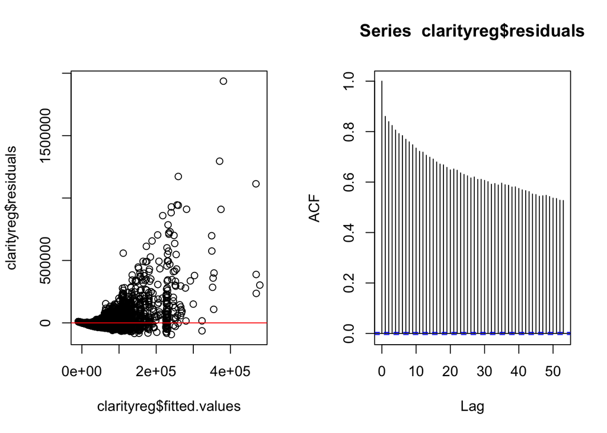

```r
par(mfrow=c(1,2))
plot(clarityreg$fitted.values,clarityreg$residuals)
abline(h=0,col="red")
acf(clarityreg$residuals)
```

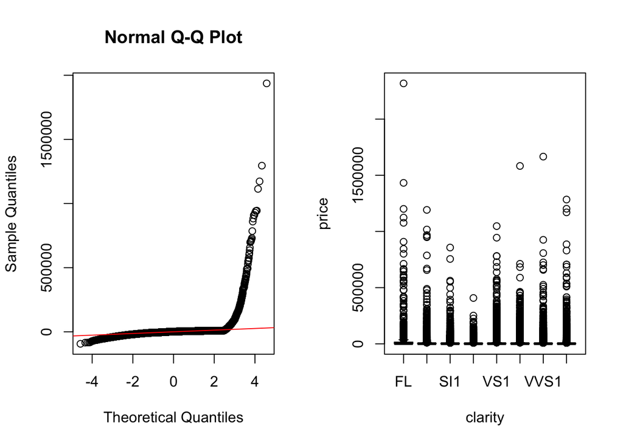

```r
qqnorm(clarityreg$residuals)
qqline(clarityreg$residuals,col="red")
boxplot(price~clarity)
```

```r
library(lawstat)
levene.test(price,clarity)
```

```
##
##  Modified robust Brown-Forsythe Levene-type test based on the absolute
##  deviations from the median
##
## data:  price
## Test Statistic = 355.73, p-value < 2.2e-16
```

Try regress price against carat and color

```r
colorreg <- lm(price~carat+color)
summary(colorreg)
```

```
##
## Call:
## lm(formula = price ~ carat + color)
##
## Residuals:
##     Min      1Q  Median      3Q     Max
##  -93835   -4379    1332    4603 1956124
##
## Coefficients:
##              Estimate Std. Error  t value Pr(>|t|)
## (Intercept) -10654.57      88.05 -121.010  < 2e-16 ***
## carat        24211.25      45.85  528.052  < 2e-16 ***
## colorE        -900.02     113.60   -7.923 2.34e-15 ***
## colorF       -1548.92     112.86  -13.725  < 2e-16 ***
## colorG       -2761.80     114.92  -24.032  < 2e-16 ***
## colorH       -3593.65     121.95  -29.468  < 2e-16 ***
## colorI       -3869.03     123.74  -31.268  < 2e-16 ***
## colorJ       -5744.66     144.43  -39.774  < 2e-16 ***
## ---
## Signif. codes:  0 '***' 0.001 '**' 0.01 '*' 0.05 '.' 0.1 ' ' 1
##
## Residual standard error: 15010 on 210630 degrees of freedom
## Multiple R-squared:  0.5701, Adjusted R-squared:  0.5701
## F-statistic: 3.99e+04 on 7 and 210630 DF,  p-value: < 2.2e-16
```

```r
anova(colorreg)
```

```
## Analysis of Variance Table
##
## Response: price
##               Df     Sum Sq    Mean Sq   F value    Pr(>F)
## carat          1 6.2388e+13 6.2388e+13 276755.98 < 2.2e-16 ***
## color          6 5.7396e+11 9.5660e+10    424.35 < 2.2e-16 ***
## Residuals 210630 4.7481e+13 2.2543e+08
## ---
## Signif. codes:  0 '***' 0.001 '**' 0.01 '*' 0.05 '.' 0.1 ' ' 1
```

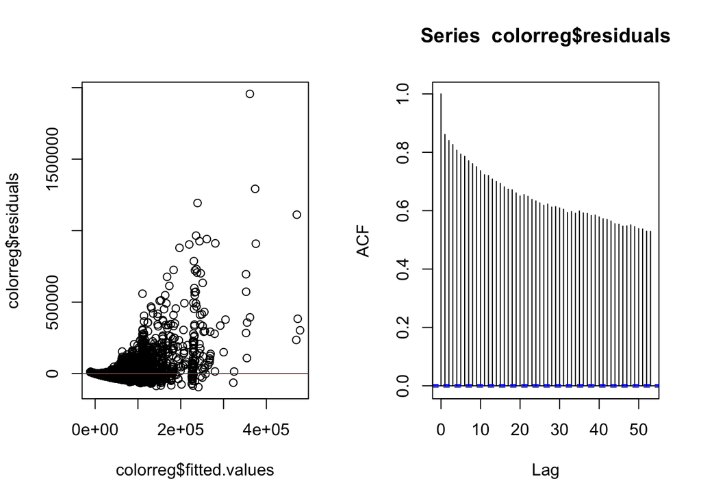

```r
par(mfrow=c(1,2))
plot(colorreg$fitted.values,colorreg$residuals)
abline(h=0,col="red")
acf(colorreg$residuals)
```

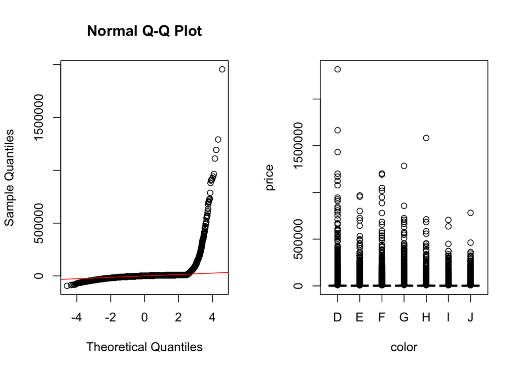

```r
qqnorm(colorreg$residuals)
qqline(colorreg$residuals,col="red")
boxplot(price~color)
```

```r
library(lawstat)
levene.test(price,color)
```

```
##
##  Modified robust Brown-Forsythe Levene-type test based on the absolute
##  deviations from the median
##
## data:  price
## Test Statistic = 29.557, p-value < 2.2e-16
```

Try regress price against carat and cut

```r
cutreg <- lm(price~carat+cut)
summary(cutreg)
```

```
##
## Call:
## lm(formula = price ~ carat + cut)
##
## Residuals:
##     Min      1Q  Median      3Q     Max
## -100085   -3959    1063    4494 1957959
##
## Coefficients:
##               Estimate Std. Error t value Pr(>|t|)
## (Intercept)  -13649.22     260.92 -52.313  < 2e-16 ***
## carat         24365.65      46.24 526.978  < 2e-16 ***
## cutGood       -2114.84     287.52  -7.355 1.91e-13 ***
## cutIdeal       1856.82     262.10   7.084 1.40e-12 ***
## cutVery Good  -1213.94     265.56  -4.571 4.85e-06 ***
## ---
## Signif. codes:  0 '***' 0.001 '**' 0.01 '*' 0.05 '.' 0.1 ' ' 1
##
## Residual standard error: 15020 on 210633 degrees of freedom
## Multiple R-squared:  0.5695, Adjusted R-squared:  0.5695
## F-statistic: 6.966e+04 on 4 and 210633 DF,  p-value: < 2.2e-16
```

```r
anova(cutreg)
```

```
## Analysis of Variance Table
##
## Response: price
##               Df     Sum Sq    Mean Sq   F value    Pr(>F)
## carat          1 6.2388e+13 6.2388e+13 276393.10 < 2.2e-16 ***
## cut            3 5.1094e+11 1.7031e+11    754.54 < 2.2e-16 ***
## Residuals 210633 4.7544e+13 2.2572e+08
## ---
## Signif. codes:  0 '***' 0.001 '**' 0.01 '*' 0.05 '.' 0.1 ' ' 1
```

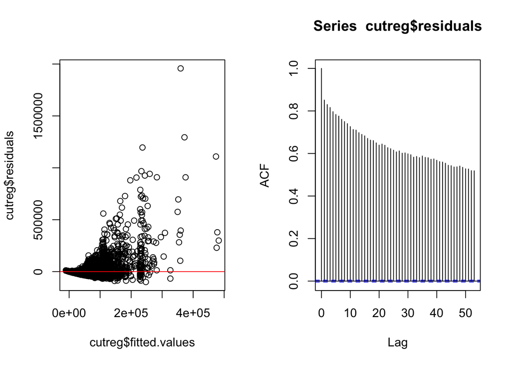

```r
par(mfrow=c(1,2))
plot(cutreg$fitted.values,cutreg$residuals)
abline(h=0,col="red")
acf(cutreg$residuals)
```

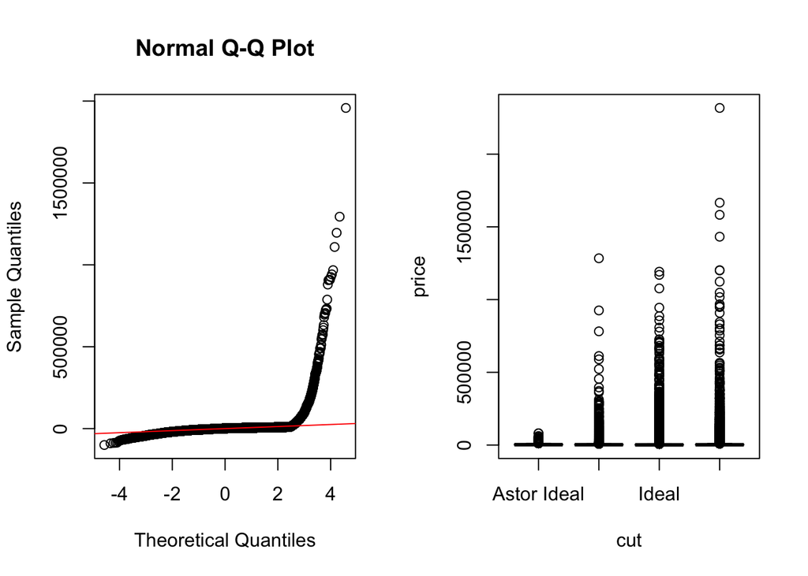

```r
qqnorm(cutreg$residuals)
qqline(cutreg$residuals,col="red")
boxplot(price~cut)
```

```r
library(lawstat)
levene.test(price,cut)
```

```
##
##  Modified robust Brown-Forsythe Levene-type test based on the absolute
##  deviations from the median
##
## data:  price
## Test Statistic = 109.36, p-value < 2.2e-16
```

Regress price against carat

```r
caratreg <- lm(price~carat)
summary(caratreg)
```

```
##
## Call:
## lm(formula = price ~ carat)
##
## Residuals:
##     Min      1Q  Median      3Q     Max
##  -95743   -4363    1799    4727 1960718
##
## Coefficients:
##              Estimate Std. Error t value Pr(>|t|)
## (Intercept) -12788.67      48.08  -266.0   <2e-16 ***
## carat        24051.21      45.99   522.9   <2e-16 ***
## ---
## Signif. codes:  0 '***' 0.001 '**' 0.01 '*' 0.05 '.' 0.1 ' ' 1
##
## Residual standard error: 15100 on 210636 degrees of freedom
## Multiple R-squared:  0.5649, Adjusted R-squared:  0.5649
## F-statistic: 2.735e+05 on 1 and 210636 DF,  p-value: < 2.2e-16
```

```r
anova(caratreg)
```

```
## Analysis of Variance Table
##
## Response: price
##               Df     Sum Sq    Mean Sq F value    Pr(>F)
## carat          1 6.2388e+13 6.2388e+13  273458 < 2.2e-16 ***
## Residuals 210636 4.8055e+13 2.2814e+08
## ---
## Signif. codes:  0 '***' 0.001 '**' 0.01 '*' 0.05 '.' 0.1 ' ' 1
```

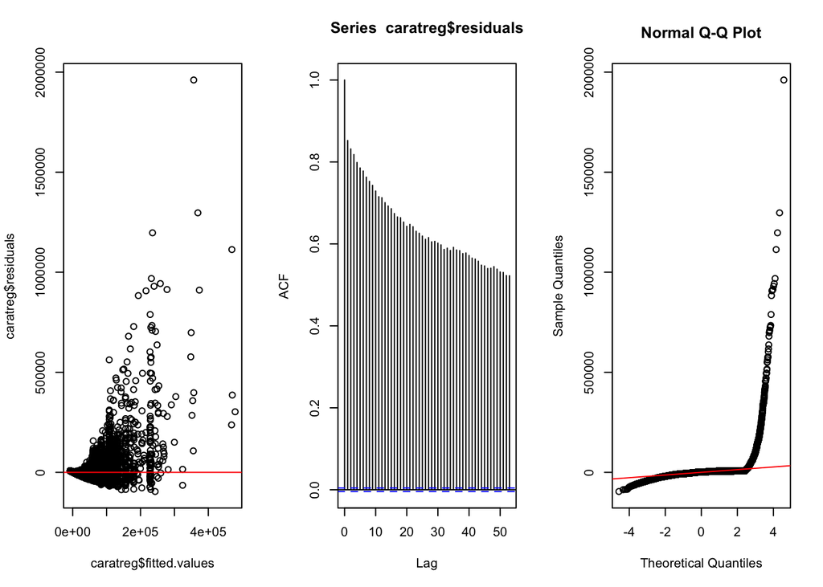

```r
par(mfrow=c(1,3))
plot(caratreg$fitted.values,caratreg$residuals)
abline(h=0,col="red")
acf(caratreg$residuals)
qqnorm(caratreg$residuals)
qqline(caratreg$residuals,col="red")
```

In summary, we can conclude that carat is the most influential indicator of diamond price. Adding cut, clarity, and color as additional predictors only slightly increased the r squared.

Data manipulation 1. regroup clarity into SI, VS, VVS, IF and FL 2. regroup color into Colorless, Near colorless and No discernible

```r
library(plyr)
data$newclarity <- revalue(data$clarity, c('SI1'='SI','SI2'='SI','VS1'='VS','VS2'='VS','VVS1'='VVS','VVS2'='VVS','IF'='IF','FL'='FL'))
data$newclarity <- mapvalues(data$clarity, from = c('SI1','SI2','VS1','VS2','VVS1','VVS2','IF','FL'), to = c('SI','SI','VS','VS','VVS','VVS','IF','FL'))
data$newcolor <- revalue(data$color, c('D'='Colorless','E'='Colorless','F'='Colorless','G'='Near colorless','H'='Near colorless','I'='No discernible','J'='No discernible'))
data$newcolor <- mapvalues(data$color, from = c('D','E','F','G','H','I','J'), to = c('Colorless','Colorless','Colorless','Near colorless','Near colorless','No discernible','No discernible'))
```

After regrouping, fit a simplified full model, no significant improvement

```r
newfullreg <- lm(data$price~data$carat+data$newclarity+data$newcolor+data$cut)
summary(newfullreg)
```

```
##
## Call:
## lm(formula = data$price ~ data$carat + data$newclarity + data$newcolor +
##     data$cut)
##
## Residuals:
##     Min      1Q  Median      3Q     Max
##  -97248   -4200    1221    4304 1932717
##
## Coefficients:
##                              Estimate Std. Error t value Pr(>|t|)
## (Intercept)                   9947.47     538.64  18.468  < 2e-16 ***
## data$carat                   24482.36      45.77 534.955  < 2e-16 ***
## data$newclarityIF           -18867.94     494.99 -38.118  < 2e-16 ***
## data$newclaritySI           -23712.31     475.49 -49.869  < 2e-16 ***
## data$newclarityVS           -22473.68     474.96 -47.317  < 2e-16 ***
## data$newclarityVVS          -20745.94     476.04 -43.581  < 2e-16 ***
## data$newcolorNear colorless  -2188.05      75.06 -29.149  < 2e-16 ***
## data$newcolorNo discernible  -3714.99      85.69 -43.353  < 2e-16 ***
## data$cutGood                 -1928.02     283.76  -6.795 1.09e-11 ***
## data$cutIdeal                 1608.86     258.61   6.221 4.94e-10 ***
## data$cutVery Good            -1362.18     262.08  -5.197 2.02e-07 ***
## ---
## Signif. codes:  0 '***' 0.001 '**' 0.01 '*' 0.05 '.' 0.1 ' ' 1
##
## Residual standard error: 14800 on 210627 degrees of freedom
## Multiple R-squared:  0.5821, Adjusted R-squared:  0.5821
## F-statistic: 2.934e+04 on 10 and 210627 DF,  p-value: < 2.2e-16
```

```r
anova(newfullreg)
```

```
## Analysis of Variance Table
##
## Response: data$price
##                     Df     Sum Sq    Mean Sq   F value    Pr(>F)
## data$carat           1 6.2388e+13 6.2388e+13 284728.18 < 2.2e-16 ***
## data$newclarity      4 1.0168e+12 2.5419e+11   1160.10 < 2.2e-16 ***
## data$newcolor        2 4.3444e+11 2.1722e+11    991.36 < 2.2e-16 ***
## data$cut             3 4.5284e+11 1.5095e+11    688.91 < 2.2e-16 ***
## Residuals       210627 4.6151e+13 2.1911e+08
## ---
## Signif. codes:  0 '***' 0.001 '**' 0.01 '*' 0.05 '.' 0.1 ' ' 1
```

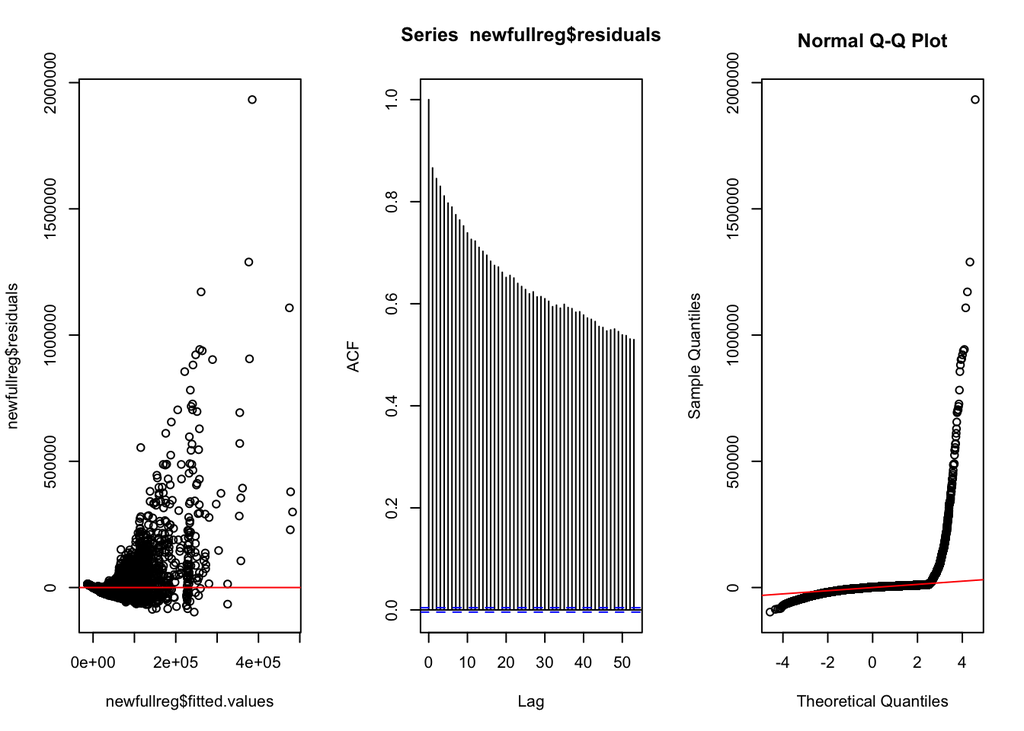

```r
fullpress <- calpress(newfullreg)
par(mfrow=c(1,3))
plot(newfullreg$fitted.values,newfullreg$residuals)
abline(h=0,col="red")
acf(newfullreg$residuals)
qqnorm(newfullreg$residuals)
qqline(newfullreg$residuals,col="red")
```

```r
logy <- log(data$price)
data$logprice <- logy
logreg <- lm(data$logprice~data$carat+data$newclarity+data$newcolor+data$cut)
summary(logreg)
```

```
##
## Call:
## lm(formula = data$logprice ~ data$carat + data$newclarity + data$newcolor +
##     data$cut)
##
## Residuals:
##      Min       1Q   Median       3Q      Max
## -22.3191  -0.4508   0.0306   0.4180   1.7294
##
## Coefficients:
##                              Estimate Std. Error t value Pr(>|t|)
## (Intercept)                  7.218859   0.022466  321.32   <2e-16 ***
## data$carat                   1.448492   0.001909  758.84   <2e-16 ***
## data$newclarityIF           -0.222203   0.020645  -10.76   <2e-16 ***
## data$newclaritySI           -0.528831   0.019832  -26.66   <2e-16 ***
## data$newclarityVS           -0.359697   0.019810  -18.16   <2e-16 ***
## data$newclarityVVS          -0.303479   0.019855  -15.29   <2e-16 ***
## data$newcolorNear colorless -0.046797   0.003131  -14.95   <2e-16 ***
## data$newcolorNo discernible -0.299467   0.003574  -83.79   <2e-16 ***
## data$cutGood                -0.292963   0.011835  -24.75   <2e-16 ***
## data$cutIdeal               -0.324824   0.010786  -30.11   <2e-16 ***
## data$cutVery Good           -0.303705   0.010931  -27.78   <2e-16 ***
## ---
## Signif. codes:  0 '***' 0.001 '**' 0.01 '*' 0.05 '.' 0.1 ' ' 1
##
## Residual standard error: 0.6174 on 210627 degrees of freedom
## Multiple R-squared:  0.7407, Adjusted R-squared:  0.7407
## F-statistic: 6.016e+04 on 10 and 210627 DF,  p-value: < 2.2e-16
```

```r
anova(logreg)
```

```
## Analysis of Variance Table
##
## Response: data$logprice
##                     Df Sum Sq Mean Sq   F value    Pr(>F)
## data$carat           1 223956  223956 587534.58 < 2.2e-16 ***
## data$newclarity      4   2276     569   1492.45 < 2.2e-16 ***
## data$newcolor        2   2731    1366   3582.85 < 2.2e-16 ***
## data$cut             3    357     119    312.57 < 2.2e-16 ***
## Residuals       210627  80287       0
## ---
## Signif. codes:  0 '***' 0.001 '**' 0.01 '*' 0.05 '.' 0.1 ' ' 1
```

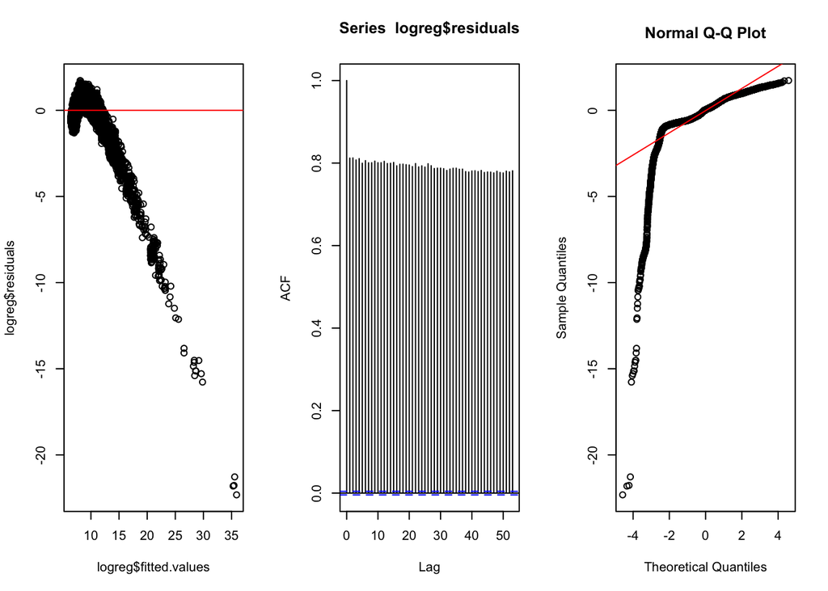

```r
logpress <- calpress(logreg)
par(mfrow=c(1,3))
plot(logreg$fitted.values,logreg$residuals)
abline(h=0,col="red")
acf(logreg$residuals)
qqnorm(logreg$residuals)
qqline(logreg$residuals,col="red")
```

R squared and adjusted R squared improved significantly, but residual plot showed a curved pattern. Since diamond price and weight (carat) are highly correlated, and as the regression model of price against carat showed, 56% of the variability in price can be explained by carat, we would also want to log transform carat after we transformed price.

```r
logx <- log(data$carat)
data$logcarat <- logx
logreg2 <- lm(data$logprice~data$logcarat+data$newclarity+data$newcolor+data$cut)
summary(logreg2)
```

```
##
## Call:
## lm(formula = data$logprice ~ data$logcarat + data$newclarity +
##     data$newcolor + data$cut)
##
## Residuals:
##      Min       1Q   Median       3Q      Max
## -0.95082 -0.11477 -0.00579  0.11023  1.29459
##
## Coefficients:
##                               Estimate Std. Error t value Pr(>|t|)
## (Intercept)                  9.3424507  0.0064166 1455.97   <2e-16 ***
## data$logcarat                1.9632715  0.0006418 3058.86   <2e-16 ***
## data$newclarityIF           -0.2978760  0.0059172  -50.34   <2e-16 ***
## data$newclaritySI           -0.7292294  0.0056830 -128.32   <2e-16 ***
## data$newclarityVS           -0.5374628  0.0056774  -94.67   <2e-16 ***
## data$newclarityVVS          -0.4263652  0.0056898  -74.94   <2e-16 ***
## data$newcolorNear colorless -0.1289843  0.0008990 -143.48   <2e-16 ***
## data$newcolorNo discernible -0.3159359  0.0010245 -308.38   <2e-16 ***
## data$cutGood                -0.3077446  0.0033931  -90.70   <2e-16 ***
## data$cutIdeal               -0.0881386  0.0030940  -28.49   <2e-16 ***
## data$cutVery Good           -0.2595581  0.0031334  -82.84   <2e-16 ***
## ---
## Signif. codes:  0 '***' 0.001 '**' 0.01 '*' 0.05 '.' 0.1 ' ' 1
##
## Residual standard error: 0.177 on 210627 degrees of freedom
## Multiple R-squared:  0.9787, Adjusted R-squared:  0.9787
## F-statistic: 9.67e+05 on 10 and 210627 DF,  p-value: < 2.2e-16
```

```r
anova(logreg2)
```

```
## Analysis of Variance Table
##
## Response: data$logprice
##                     Df Sum Sq Mean Sq F value    Pr(>F)
## data$logcarat        1 294166  294166 9388006 < 2.2e-16 ***
## data$newclarity      4   4356    1089   34755 < 2.2e-16 ***
## data$newcolor        2   2869    1434   45773 < 2.2e-16 ***
## data$cut             3   1616     539   17189 < 2.2e-16 ***
## Residuals       210627   6600       0
## ---
## Signif. codes:  0 '***' 0.001 '**' 0.01 '*' 0.05 '.' 0.1 ' ' 1
```

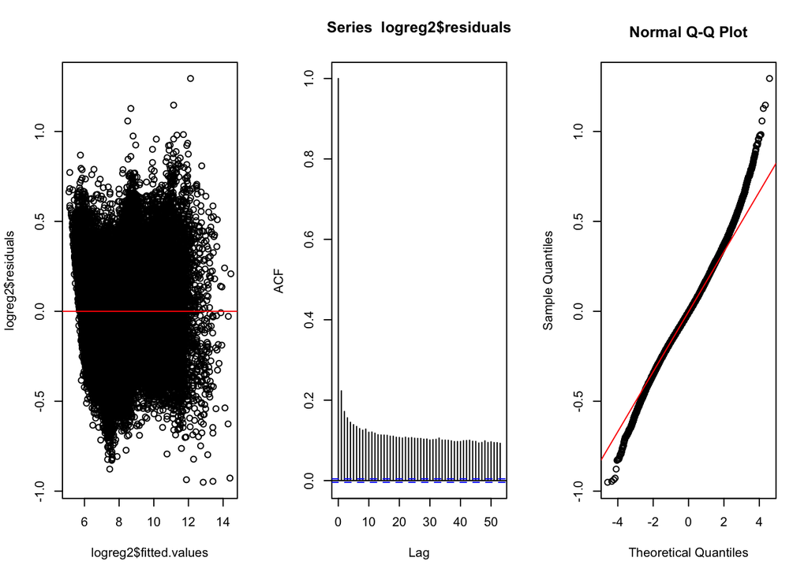

```r
logpress2 <- calpress(logreg2)
par(mfrow=c(1,3))
plot(logreg2$fitted.values,logreg2$residuals)
abline(h=0,col="red")
acf(logreg2$residuals)
qqnorm(logreg2$residuals)
qqline(logreg2$residuals,col="red")
```

```r
library(lawstat)
levene.test(data$logprice,data$newclarity)
```

```
##
##  Modified robust Brown-Forsythe Levene-type test based on the absolute
##  deviations from the median
##
## data:  data$logprice
## Test Statistic = 134.15, p-value < 2.2e-16
```

```r
levene.test(data$logprice,data$newcolor)
```

```
##
##  Modified robust Brown-Forsythe Levene-type test based on the absolute
##  deviations from the median
##
## data:  data$logprice
## Test Statistic = 2.8208, p-value = 0.05956
```

```r
levene.test(data$logprice,data$cut)
```

```
##
##  Modified robust Brown-Forsythe Levene-type test based on the absolute
##  deviations from the median
##
## data:  data$logprice
## Test Statistic = 110.54, p-value < 2.2e-16
```

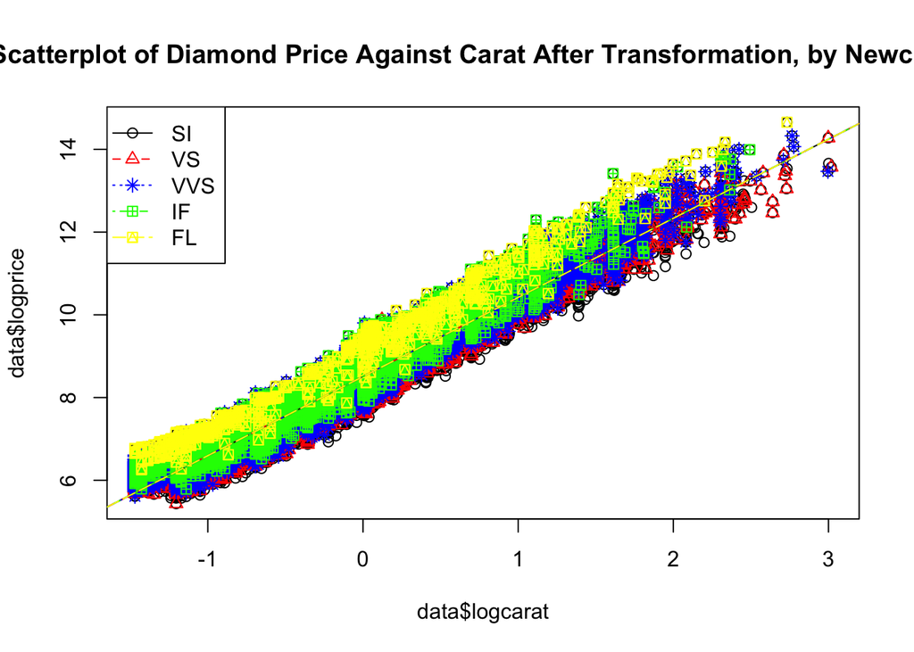

```r
clarity1<-subset(data,newclarity=="SI")
clarity2<-subset(data,newclarity=="VS")
clarity3<-subset(data,newclarity=="VVS")
clarity4<-subset(data,newclarity=="IF")
clarity5<-subset(data,newclarity=="FL")
regclarity1<-lm(data$logprice~data$logcarat,data=clarity1)
regclarity2<-lm(data$logprice~data$logcarat,data=clarity2)
regclarity3<-lm(data$logprice~data$logcarat,data=clarity3)
regclarity4<-lm(data$logprice~data$logcarat,data=clarity4)
regclarity5<-lm(data$logprice~data$logcarat,data=clarity5)

plot(data$logprice~data$logcarat, main='Scatterplot of Diamond Price Against Carat After Transformation, by Newclarity')
points(clarity2$logcarat,clarity2$logprice, pch=2, col="red")
points(clarity3$logcarat,clarity3$logprice, pch=8, col="blue")
points(clarity4$logcarat,clarity4$logprice, pch=12, col="green")
points(clarity5$logcarat,clarity5$logprice, pch=14, col="yellow")
abline(regclarity1,lty=1)
abline(regclarity2,lty=2, col="red")
abline(regclarity3,lty=3, col="blue")
abline(regclarity4,lty=4, col="green")
abline(regclarity5,lty=5, col="yellow")
legend("topleft", c("SI","VS","VVS","IF", "FL"), lty=c(1,2,3,4,5), pch=c(1,2,8,12,14), col=c("black","red","blue","green","yellow"))
```

Subset cut into four classes

```r
cut1<-subset(data,cut=="Very Good")
cut2<-subset(data,cut=="Good")
cut3<-subset(data,cut=="Ideal")
cut4<-subset(data,cut=="Astor Ideal")
regcut1<-lm(data$logprice~data$logcarat,data=cut1)
regcut2<-lm(data$logprice~data$logcarat,data=cut2)
regcut3<-lm(data$logprice~data$logcarat,data=cut3)
regcut4<-lm(data$logprice~data$logcarat,data=cut4)
```

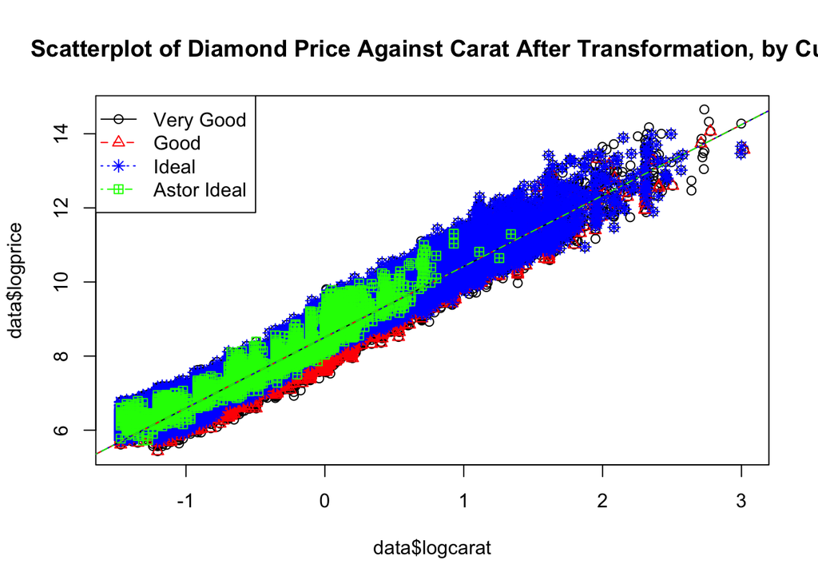

```r
plot(data$logprice~data$logcarat, main='Scatterplot of Diamond Price Against Carat After Transformation, by Cut')
points(cut2$logcarat,cut2$logprice, pch=2, col="red")
points(cut3$logcarat,cut3$logprice, pch=8, col="blue")
points(cut4$logcarat,cut4$logprice, pch=12, col="green")
abline(regcut1,lty=1)
abline(regcut2,lty=2, col="red")
abline(regcut3,lty=3, col="blue")
abline(regcut4,lty=4, col="green")
legend("topleft", c("Very Good","Good","Ideal","Astor Ideal"), lty=c(1,2,3,4), pch=c(1,2,8,12), col=c("black","red","blue","green"))
```

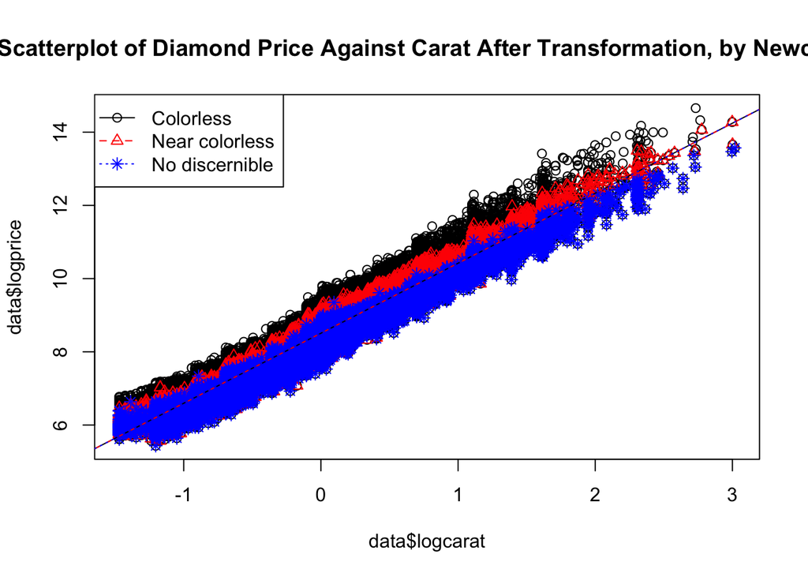

```r
color1<-subset(data,newcolor=="Colorless")
color2<-subset(data,newcolor=="Near colorless")
color3<-subset(data,newcolor=="No discernible")
regcolor1<-lm(data$logprice~data$logcarat,data=color1)
regcolor2<-lm(data$logprice~data$logcarat,data=color2)
regcolor3<-lm(data$logprice~data$logcarat,data=color3)
plot(data$logprice~data$logcarat, main='Scatterplot of Diamond Price Against Carat After Transformation, by Newcolor')
points(color2$logcarat,color2$logprice, pch=2, col="red")
points(color3$logcarat,color3$logprice, pch=8, col="blue")
abline(regcolor1,lty=1)
abline(regcolor2,lty=2, col="red")
abline(regcolor3,lty=3, col="blue")
legend("topleft", c("Colorless","Near colorless","No discernible"), lty=c(1,2,3), pch=c(1,2,8), col=c("black","red","blue"))
```

```r
detach(data)
```

Unable to produce Bocox plots and tukey tests

PRESS: fullnewreg 46253149887104, logpress 80340, logpress2 6600 R squared: full model before transformation 0.5829, full model after regrouping 0.5821, logy model 0.7407, logy,loyx model 0.9787 AdjR squared: same as R squared because large sample size compared to the number of parameters

The most influential predictor is carat

linear regression equation: logPrice = 1.9632715*logCarat+9.3424507 (FL+Colorless+Aster Ideal) logPrice = 1.9632715*logCarat+(9.3424507-0.2978760) (IF+Colorless+Aster Ideal) logPrice = 1.9632715*logCarat+(9.3424507-0.7292294) (SI+Colorless+Aster Ideal) logPrice = 1.9632715*logCarat+(9.3424507-0.4263652) (VVS+Colorless+Aster Ideal) logPrice = 1.9632715*logCarat+(9.3424507-0.5374628) (VS+Colorless+Aster Ideal) logPrice = 1.9632715*logCarat+(9.3424507-0.1289843) (FL+Near-colorless+Aster Ideal) logPrice = 1.9632715*logCarat+(9.3424507-0.3159359) (FL+No discernible+Aster Ideal) logPrice = 1.9632715*logCarat+(9.3424507-0.3077446) (FL+Colorless+Good) logPrice = 1.9632715*logCarat+(9.3424507-0.0881386) (FL+Colorless+Ideal) logPrice = 1.9632715*logCarat+(9.3424507-0.2595581) (FL+Colorless+Very Good) logPrice = 1.9632715*logCarat+(9.3424507-0.2595581-0.2978760) (IF+Colorless+Very Good) logPrice = 1.9632715*logCarat+(9.3424507-0.2595581-0.7292294) (SI+Colorless+Very Good) logPrice = 1.9632715*logCarat+(9.3424507-0.2595581-0.4263652) (VVS+Colorless+Very Good) logPrice = 1.9632715*logCarat+(9.3424507-0.2595581-0.5374628) (VS+Colorless+Very Good) ….continued